# NBA Career Comparison: Jamal Crawford vs. Lou Williams

This notebook provides a comprehensive analysis comparing the NBA careers of Jamal Crawford and Lou Williams, two of the greatest sixth men in NBA history. We'll analyze their career statistics, identify their peak years, and create visualizations to determine who had the better career.

## Setup and Data Preparation

First, let's import the necessary libraries and set up our environment.

## Player Data

Let's define the career data for both players.

| Player | Seasons | Games | PPG | RPG | APG | FG% | 3P% | FT% | PER | WS | Sixth_Man_Awards |
| --- | --- | --- | --- | --- | --- | --- | --- | --- | --- | --- | --- |
| Jamal Crawford | 20 | 1327 | 14.6 | 2.2 | 3.4 | 41.0 | 34.8 | 86.2 | 15.1 | 60.7 | 3 |
| Lou Williams | 17 | 1123 | 13.9 | 2.2 | 3.4 | 41.9 | 35.1 | 84.2 | 18.0 | 65.7 | 3 |

## Career Statistics Analysis

Let's calculate additional metrics and analyze their career statistics.

| Player | Points_Per_Season | Points_Per_Game | Games_Per_Season |
| --- | --- | --- | --- |
| Jamal Crawford | 970.950000 | 14.633760 | 66.350000 |
| Lou Williams | 917.235294 | 13.885129 | 66.058824 |

## Basic Visualizations

Let's create some basic visualizations to compare their career statistics.

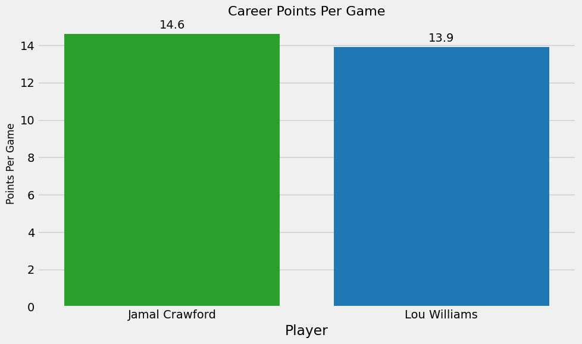

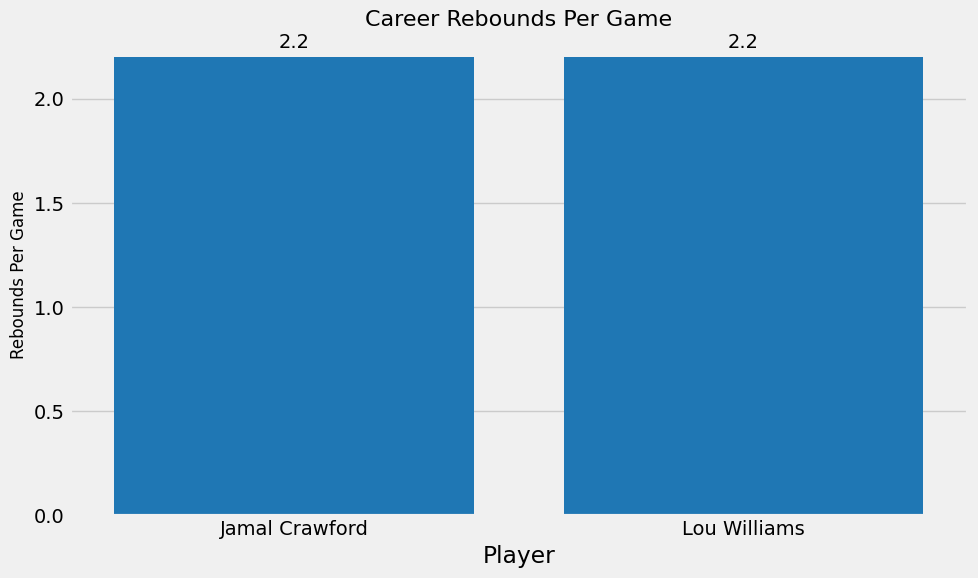

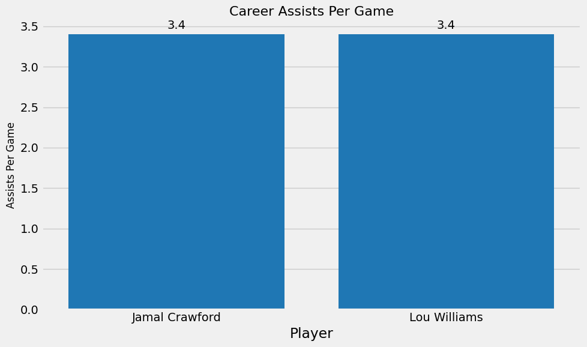

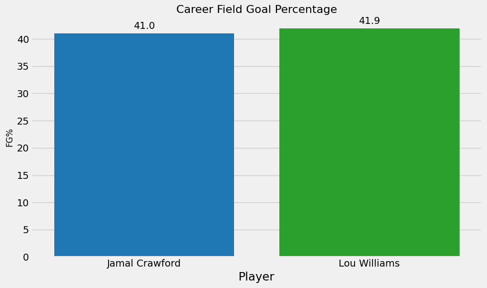

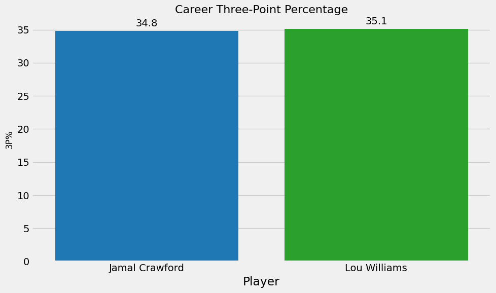

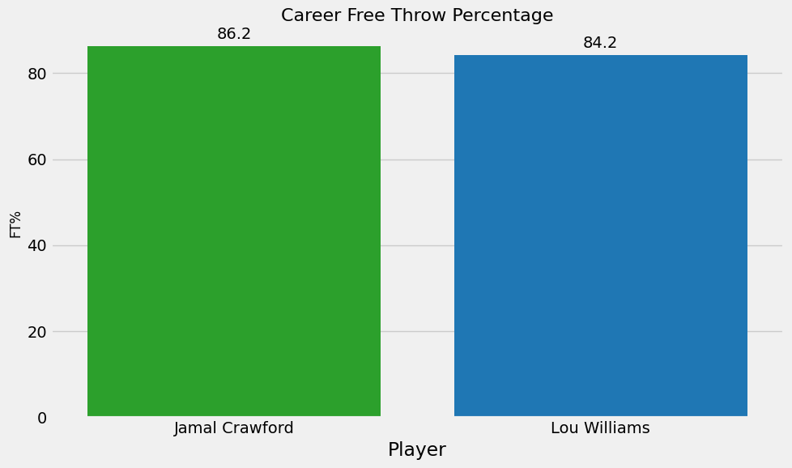

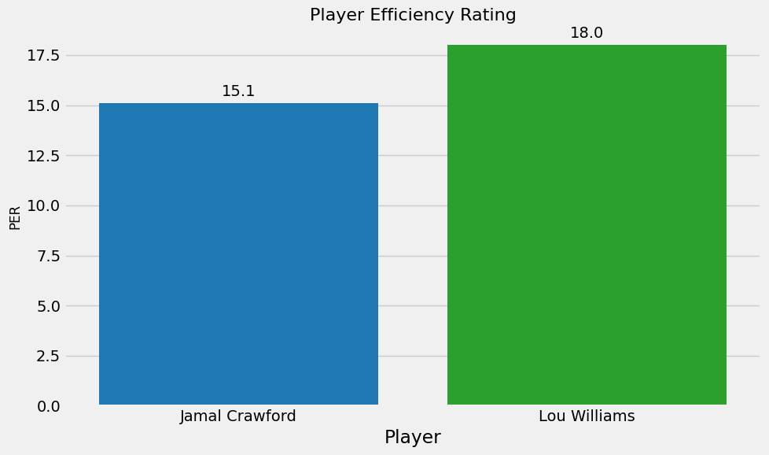

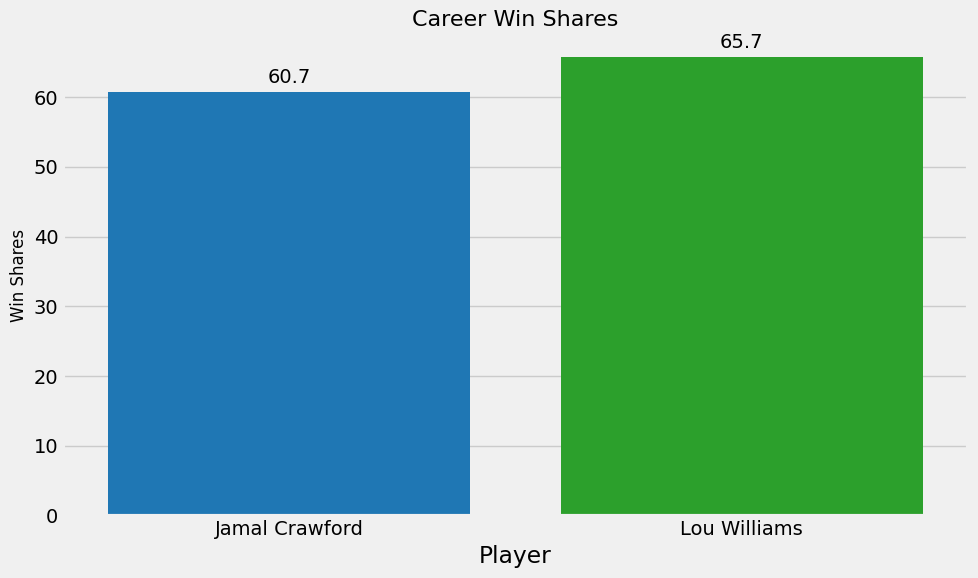

## Season-by-Season Data

Let's define their season-by-season data to analyze their career trajectories and identify peak years.

```
Jamal Crawford Season Data:
```

|  | Season | Team | PPG | PER | WS |
| --- | --- | --- | --- | --- | --- |
| 0 | 2000-01 | CHI | 4.6 | 11.1 | 1.4 |
| 1 | 2001-02 | CHI | 9.3 | 14.3 | 1.4 |
| 2 | 2002-03 | CHI | 10.7 | 14.0 | 3.0 |
| 3 | 2003-04 | CHI | 17.3 | 16.8 | 4.6 |
| 4 | 2004-05 | NYK | 17.7 | 15.7 | 4.4 |

```
Lou Williams Season Data:
```

|  | Season | Team | PPG | PER | WS |
| --- | --- | --- | --- | --- | --- |
| 0 | 2005-06 | PHI | 1.9 | 8.8 | 0.3 |
| 1 | 2006-07 | PHI | 4.3 | 13.3 | 2.0 |
| 2 | 2007-08 | PHI | 11.5 | 17.3 | 5.3 |
| 3 | 2008-09 | PHI | 12.8 | 16.8 | 4.9 |
| 4 | 2009-10 | PHI | 14.0 | 19.7 | 6.3 |

## Career Trajectory Visualization

Let's visualize their career trajectories in terms of scoring.

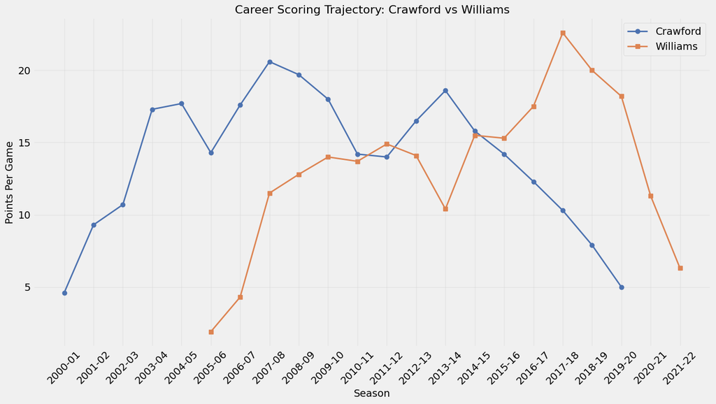

## Peak Years Identification

Let's identify the peak years for both players based on multiple metrics.

```
Jamal Crawford's Peak Years:
```

|  | Season | Team | PPG | RPG | APG | FG% | 3P% | PER | WS |
| --- | --- | --- | --- | --- | --- | --- | --- | --- | --- |
| 7 | 2007-08 | NYK | 20.6 | 2.6 | 5.0 | 41.0 | 36.0 | 16.8 | 7.0 |
| 3 | 2003-04 | CHI | 17.3 | 3.5 | 5.1 | 38.6 | 30.0 | 16.8 | 4.6 |
| 13 | 2013-14 | LAC | 18.6 | 2.3 | 3.2 | 41.6 | 36.1 | 16.8 | 4.9 |

```
Lou Williams' Peak Years:
```

|  | Season | Team | PPG | RPG | APG | FG% | 3P% | PER | WS |
| --- | --- | --- | --- | --- | --- | --- | --- | --- | --- |
| 12 | 2017-18 | LAC | 22.6 | 2.5 | 5.3 | 43.5 | 35.9 | 22.6 | 8.3 |
| 13 | 2018-19 | LAC | 20.0 | 3.0 | 5.4 | 42.5 | 36.1 | 21.2 | 7.1 |
| 11 | 2016-17 | LAL/HOU | 17.5 | 3.0 | 3.0 | 42.9 | 36.5 | 18.6 | 7.7 |

## Peak Years Visualization

Let's visualize their career trajectories with peak years highlighted.

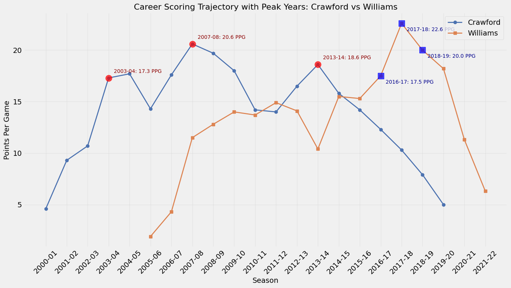

## Peak Years Comparison

Let's compare their peak years across different metrics.

|  | Crawford Peak | Williams Peak | Advantage |
| --- | --- | --- | --- |
| PPG | 18.833333 | 20.033333 | Williams |
| RPG | 2.800000 | 2.833333 | Williams |
| APG | 4.433333 | 4.566667 | Williams |
| FG% | 40.400000 | 42.966667 | Williams |
| 3P% | 34.033333 | 36.166667 | Williams |
| PER | 16.800000 | 20.800000 | Williams |
| WS | 5.500000 | 7.700000 | Williams |

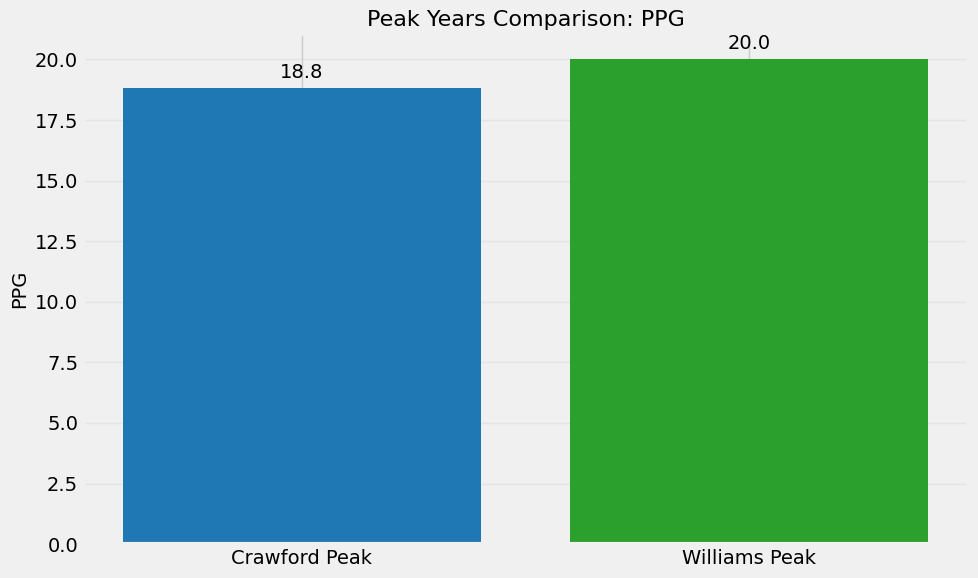

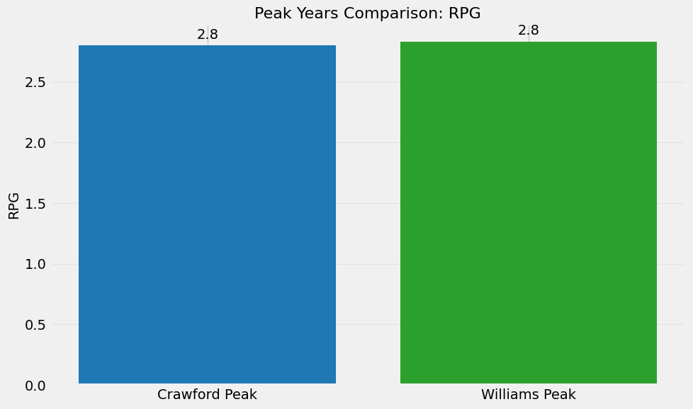

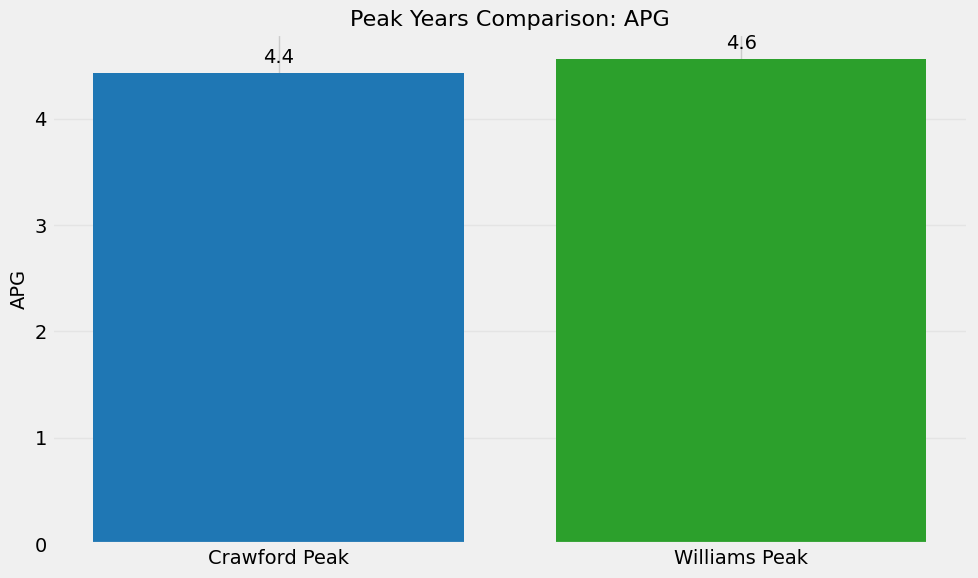

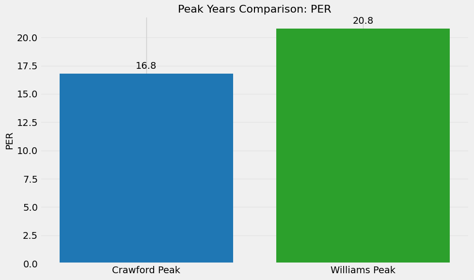

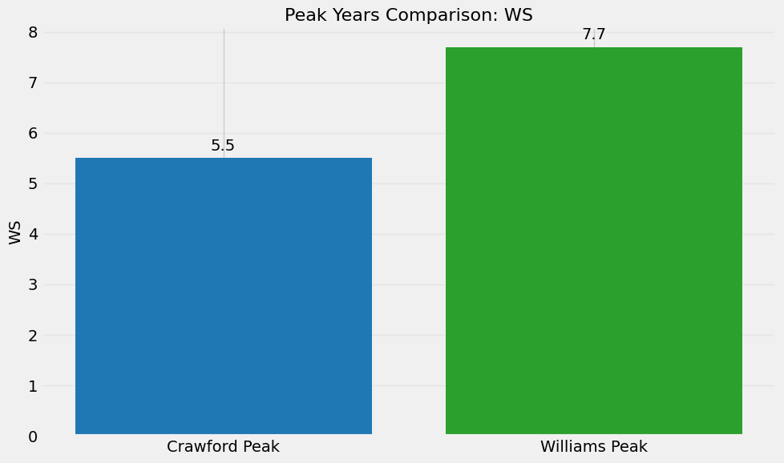

## Radar Chart for Overall Comparison

Let's create a radar chart to visualize their overall statistical profiles.

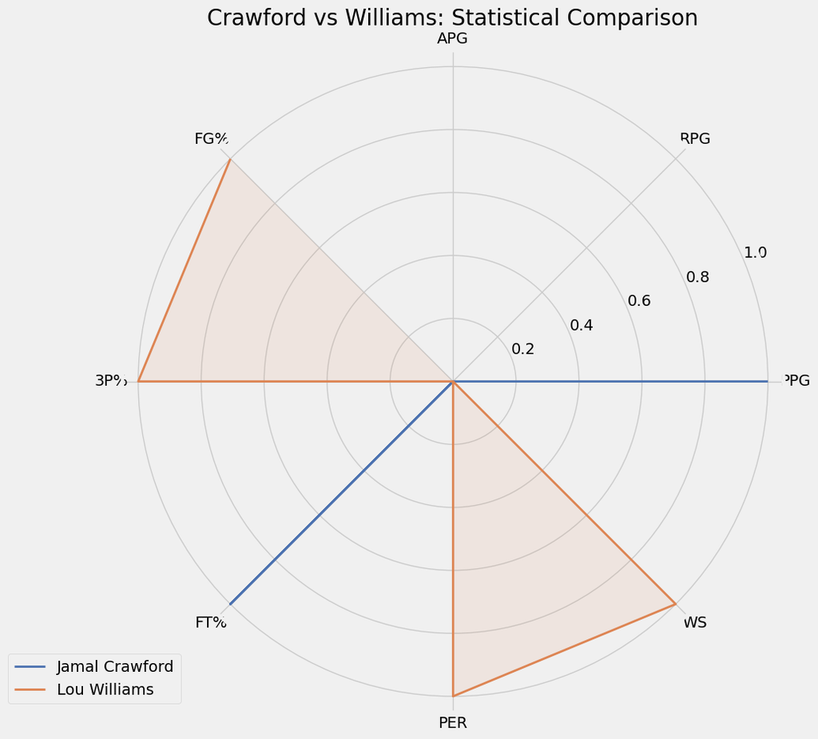

## Regular Season vs Playoffs Comparison

Let's compare their regular season and playoff performances.

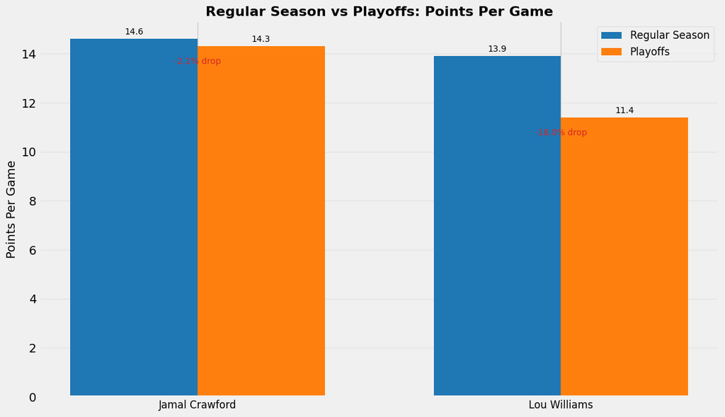

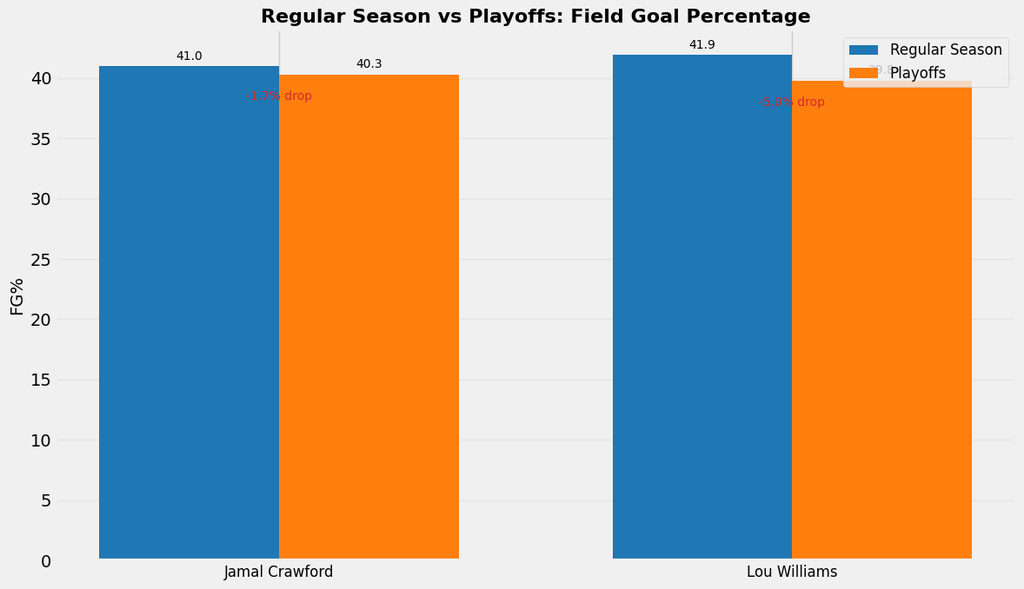

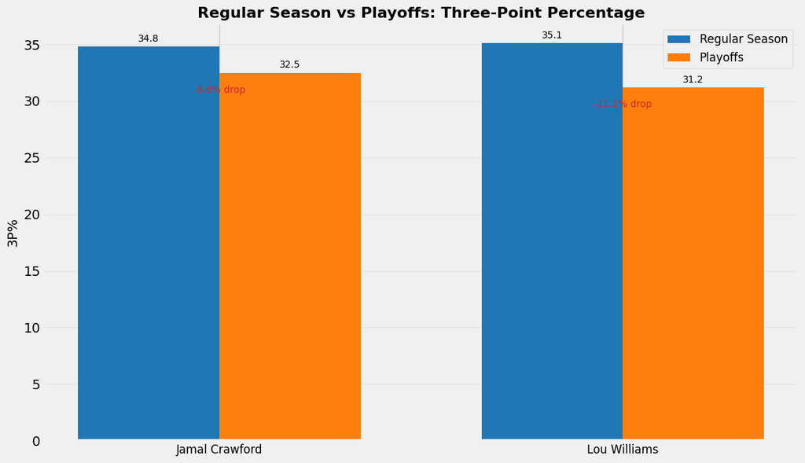

## Comprehensive Dashboard

Let's create a comprehensive dashboard that provides an overview of their careers.

[figure not shown]

## Conclusion

Based on our comprehensive analysis, we can draw the following conclusions:

### Overall Career Assessment

The overall career comparison presents a more nuanced picture:

### Final Verdict

Based on the comprehensive analysis of their statistics, achievements, and impact, **Lou Williams had the better overall NBA career** by a narrow margin, with his superior efficiency, advanced metrics, and exceptional peak years outweighing Crawford's advantages in longevity and total counting statistics.